# Random Stats of Blowjob 2012-2015: Summary

Various interesting statistics for all posts on reddit.com/r/randomactsofblowjob from subreddit creation on 11 March 2012 until 10 October 2015. For raw stats on every individual matched location, see all locations stats. For smaller scale maps not included in the summary, see maps.

## Posts by year

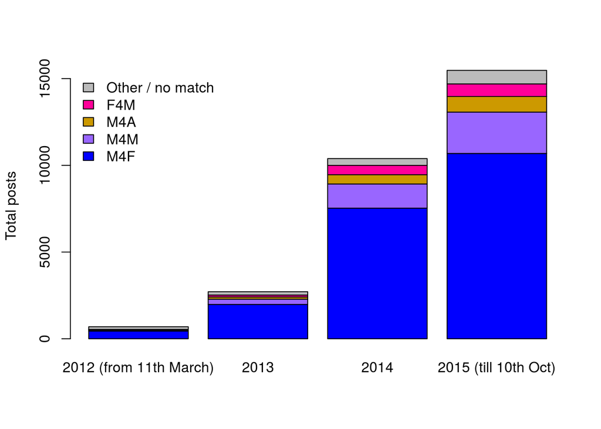

Posts by number

| Year | Total posts | M4F posts | M4M posts | M4A posts | F4M posts | Other / no match posts |
| --- | --- | --- | --- | --- | --- | --- |
| 2012 | 695 | 441 | 62 | 18 | 22 | 152 |
| 2013 | 2713 | 1981 | 305 | 126 | 109 | 192 |
| 2014 | 10387 | 7531 | 1394 | 531 | 541 | 390 |
| 2015 | 15473 | 10683 | 2383 | 901 | 726 | 780 |

Posts by %

| Year | M4F % | M4M % | M4A % | F4M % | Other / no match % |
| --- | --- | --- | --- | --- | --- |
| 2012 | 63.5 | 8.9 | 2.6 | 3.2 | 21.9 |
| 2013 | 73.0 | 11.2 | 4.6 | 4.0 | 7.1 |
| 2014 | 72.5 | 13.4 | 5.1 | 5.2 | 3.8 |
| 2015 | 69.0 | 15.4 | 5.8 | 4.7 | 5.0 |

## Average upvotes per post by post type

| M4F | F4M | M4M | M4A | T4M | M4T | Success |
| --- | --- | --- | --- | --- | --- | --- |
| 1.4 | 33.3 | 2.1 | 1.8 | 6.1 | 2.6 | 55.4 |

# Age distribution (18 - 50)

Age matches outside this range were very few and mostly false matches.

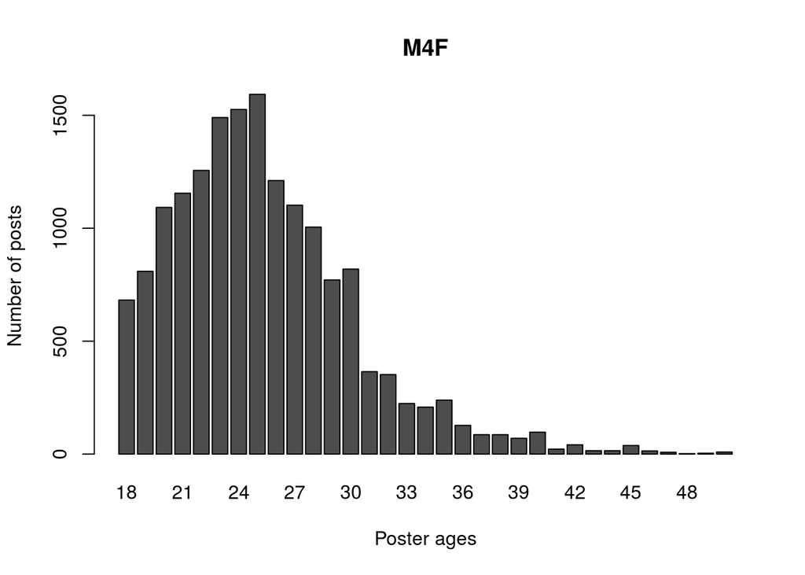

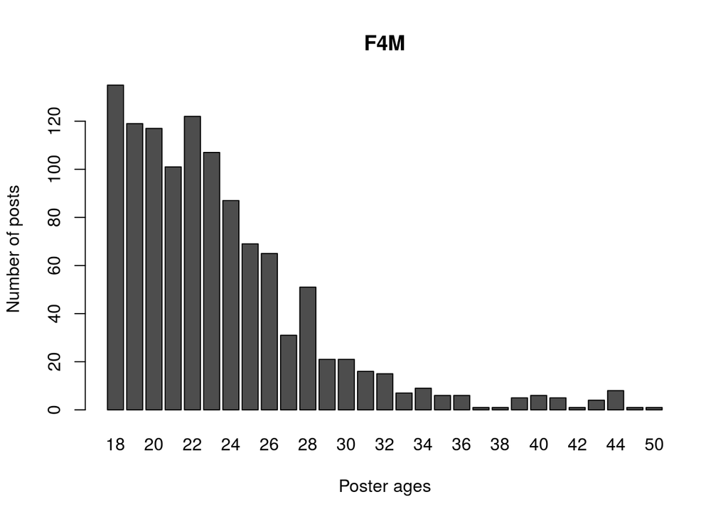

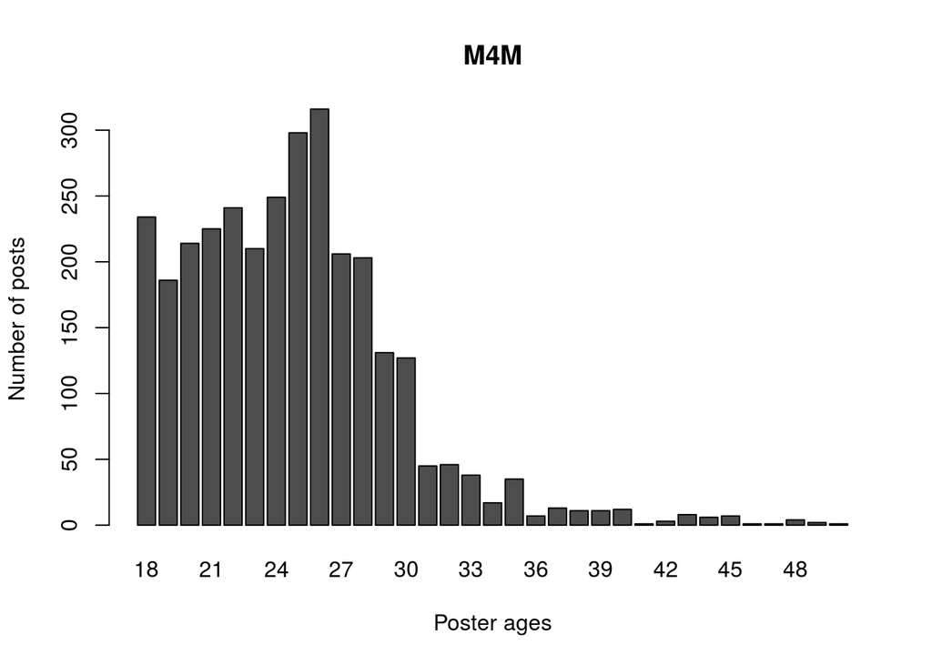

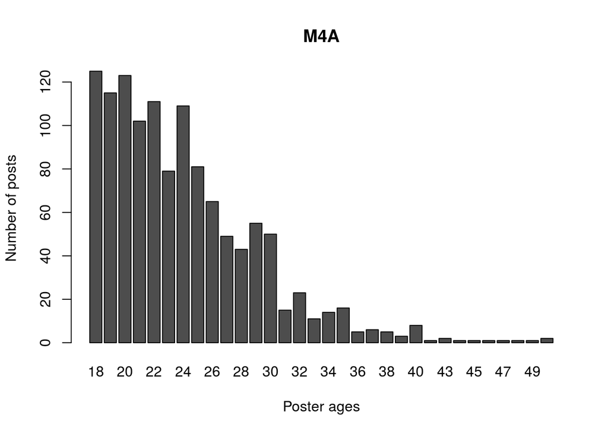

# Locations by total posts

See locations list for stats on all 1435 matched post locations.

## Top 15 total posts by location

- The M4F to F4M ratio for all posts in all locations is 14.8
- The Non-M4M to M4M ratio for all posts in all locations is 6.1

| Location | Total posts | M4F posts | M4M posts | F4M posts | M4A posts | Success posts | M4F to F4M ratio | Non M4M to M4M ratio | Non success to success ratio* |
| --- | --- | --- | --- | --- | --- | --- | --- | --- | --- |
| New York, NY, United States | 1890 | 1132 | 385 | 148 | 107 | 20 | 7.6 | 3.9 | 93.5 |
| Los Angeles, CA, United States | 1462 | 1044 | 157 | 106 | 64 | 18 | 9.8 | 8.3 | 80.2 |
| Chicago, IL, United States | 1063 | 665 | 242 | 40 | 64 | 5 | 16.6 | 3.4 | 211.6 |
| Toronto, Canada | 837 | 634 | 108 | 49 | 17 | 13 | 12.9 | 6.8 | 63.4 |
| Boston, MA, United States | 717 | 510 | 116 | 30 | 28 | 9 | 17.0 | 5.2 | 78.7 |
| London, United Kingdom | 623 | 396 | 86 | 68 | 35 | 7 | 5.8 | 6.2 | 88.0 |
| New Jersey, United States | 567 | 418 | 84 | 16 | 26 | 3 | 26.1 | 5.8 | 188.0 |
| Seattle, WA, United States | 562 | 377 | 104 | 28 | 34 | 2 | 13.5 | 4.4 | 280.0 |
| Washington, DC, United States | 521 | 392 | 68 | 21 | 15 | 1 | 18.7 | 6.7 | 520.0 |
| Philadelphia, PA, United States | 519 | 337 | 105 | 21 | 33 | 4 | 16.0 | 3.9 | 128.8 |
| Dallas, TX, United States | 502 | 301 | 101 | 28 | 38 | 6 | 10.8 | 4.0 | 82.7 |
| Bay Area, CA, United States | 484 | 353 | 46 | 28 | 20 | 6 | 12.6 | 9.5 | 79.7 |
| Houston, TX, United States | 456 | 332 | 74 | 12 | 21 | 4 | 27.7 | 5.2 | 113.0 |
| San Diego, CA, United States | 448 | 321 | 62 | 15 | 23 | 3 | 21.4 | 6.2 | 148.3 |
| Austin, TX, United States | 415 | 331 | 39 | 10 | 18 | 3 | 33.1 | 9.6 | 137.3 |

## Maps

**For smaller scale maps not included in this summary (NW Europe, NE USA, SE USA, California, Asia & Australasia), see maps.**

Area of circles is directly proportional to total number of posts for that location (hence why they all overlap on world map. See other maps for more detail). The smallest circles are for a location with a single post.

‘City’ means posts specifying a certain city or local area, ‘Region’ means posts specifying a broad area (region, US state, UK county etc.), ‘Country’ is for posts specifying a whole country.

I just realised this map still has the Soviet Union! Sorry Latvia…

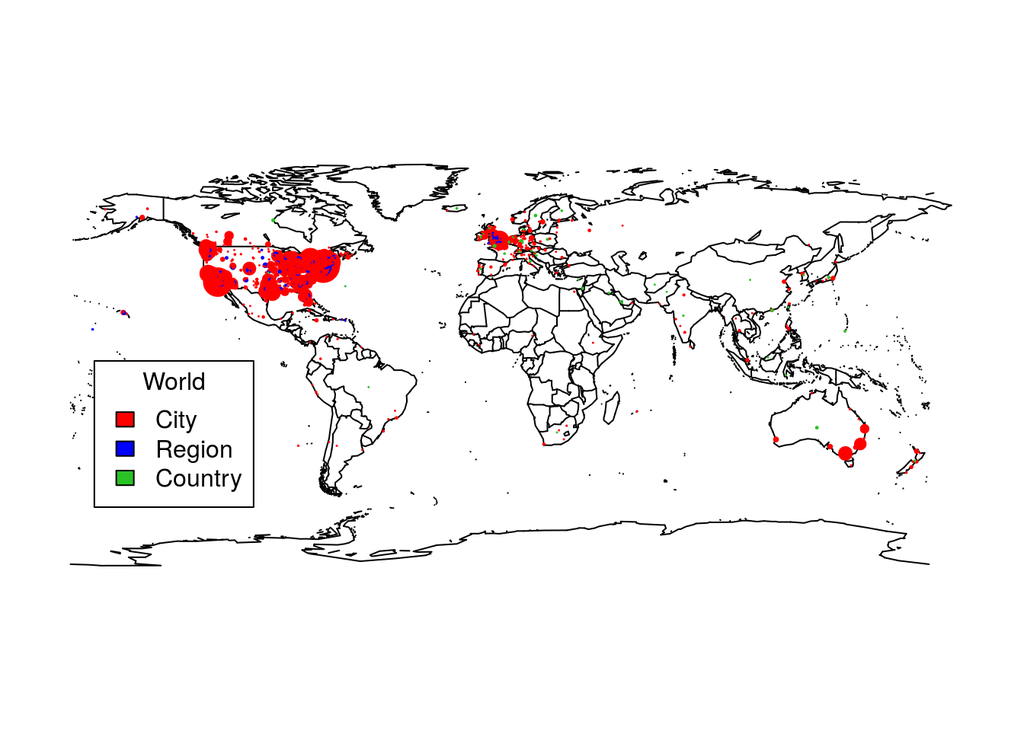

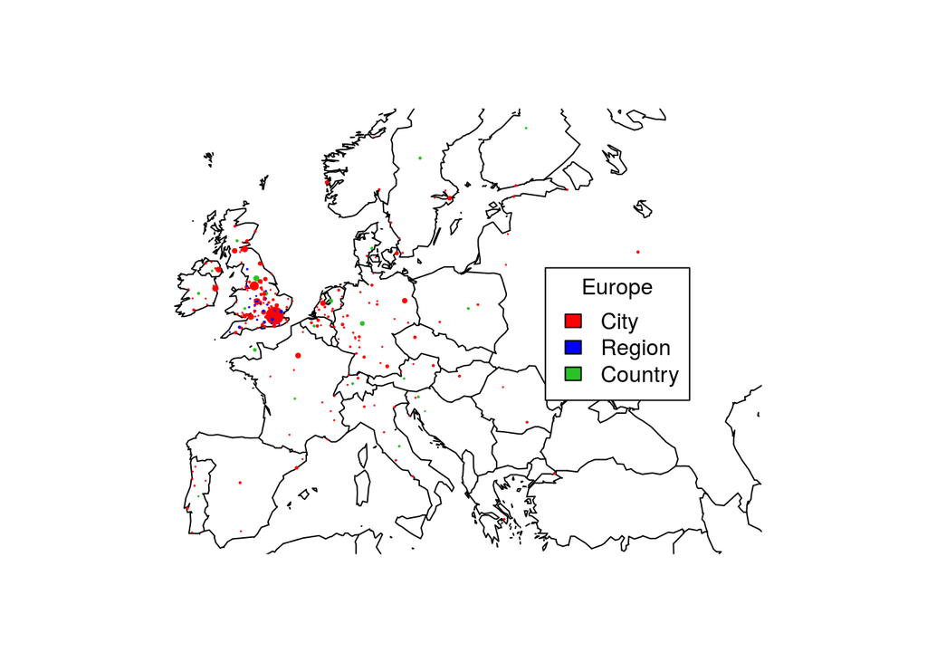

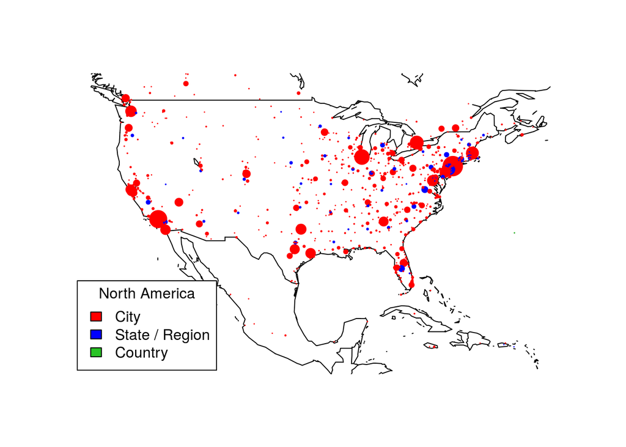

# Ratios for locations

See all locations stats for ratios for all locations.

## Ratio of M4F posts to F4M posts by location

- The M4F to F4M ratio for all posts in all locations is 14.8
- Only locations with at least 5 F4M posts are included in the first two tables, so as to aim for some sort of statistical significance

### Top 15 lowest ratio (‘Lesser sausagefests’)

| Location | M4F posts | F4M posts | M4F to F4M ratio |
| --- | --- | --- | --- |
| Eugene, OR, United States | 12 | 7 | 1.7 |
| Burlington, VT, United States | 12 | 6 | 2.0 |
| Berkeley, CA, United States | 22 | 9 | 2.4 |
| Toledo, OH, United States | 21 | 7 | 3.0 |
| Southern California, United States | 47 | 13 | 3.6 |
| Edinburgh, United Kingdom | 37 | 8 | 4.6 |
| London, United Kingdom | 396 | 68 | 5.8 |
| Glasgow, United Kingdom | 29 | 5 | 5.8 |
| Boulder, CO, United States | 29 | 5 | 5.8 |
| Harrisburg, PA, United States | 48 | 8 | 6.0 |
| North Carolina, United States | 49 | 8 | 6.1 |
| Tempe, AZ, United States | 45 | 7 | 6.4 |
| New York, NY, United States | 1132 | 148 | 7.6 |
| Montreal, Canada | 159 | 19 | 8.4 |
| Brisbane, Australia | 84 | 10 | 8.4 |

### Top 15 highest ratio (‘Greater sausagefests’)

| Location | M4F posts | F4M posts | M4F to F4M ratio |
| --- | --- | --- | --- |
| Austin, TX, United States | 331 | 10 | 33.1 |
| Portland, OR, United States | 152 | 5 | 30.4 |
| Houston, TX, United States | 332 | 12 | 27.7 |
| New Jersey, United States | 418 | 16 | 26.1 |
| Minneapolis, MN, United States | 142 | 6 | 23.7 |
| Las Vegas, NV, United States | 230 | 10 | 23.0 |
| Phoenix, AZ, United States | 137 | 6 | 22.8 |
| San Diego, CA, United States | 321 | 15 | 21.4 |
| Vancouver, Canada | 212 | 10 | 21.2 |
| Orlando, FL, United States | 187 | 9 | 20.8 |
| Florida, United States | 138 | 7 | 19.7 |
| Washington, DC, United States | 392 | 21 | 18.7 |
| Long Island, NY, United States | 108 | 6 | 18.0 |
| Connecticut, United States | 104 | 6 | 17.3 |
| Pittsburgh, PA, United States | 137 | 8 | 17.1 |

### Top 15 M4F posts with no F4M posts (‘Total sausagefests’)

| Location | M4F posts | F4M posts | M4F to F4M ratio |
| --- | --- | --- | --- |
| Tampa, FL, United States | 109 | 0 | Inf |
| Memphis, TN, United States | 57 | 0 | Inf |
| Delaware, United States | 52 | 0 | Inf |
| Pennsylvania, United States | 47 | 0 | Inf |
| Dublin, Ireland | 42 | 0 | Inf |
| Gainesville, FL, United States | 35 | 0 | Inf |
| Louisville, KY, United States | 35 | 0 | Inf |
| Paris, France | 35 | 0 | Inf |
| Perth, Australia | 31 | 0 | Inf |
| Ann Arbor, MI, United States | 29 | 0 | Inf |
| Baton Rouge, LA, United States | 28 | 0 | Inf |
| Syracuse, NY, United States | 28 | 0 | Inf |
| Fort Lauderdale, FL, United States | 27 | 0 | Inf |
| Westchester, NY, United States | 25 | 0 | Inf |
| Halifax, Canada | 23 | 0 | Inf |

## Ratio of M4M posts to non M4M posts by location

- The Non-M4M to M4M ratio for all posts in all locations is 6.1
- Only locations with at least 10 M4M posts are included in these tables

### Top 15 lowest ratio (‘Go homo’)

| Location | Non M4M posts | M4M posts | Non M4M to M4M ratio |
| --- | --- | --- | --- |
| Pomona, CA, United States | 5 | 10 | 0.5 |
| Kitchener, Canada | 16 | 10 | 1.6 |
| Oklahoma City, OK, United States | 96 | 47 | 2.0 |
| Manchester, United Kingdom | 89 | 45 | 2.0 |
| Massachusetts, United States | 58 | 28 | 2.1 |
| Fresno, CA, United States | 45 | 14 | 3.2 |
| Minneapolis, MN, United States | 167 | 51 | 3.3 |
| Chicago, IL, United States | 821 | 242 | 3.4 |
| New Hampshire, United States | 37 | 11 | 3.4 |
| Portland, OR, United States | 189 | 54 | 3.5 |
| New York, NY, United States | 1505 | 385 | 3.9 |
| Philadelphia, PA, United States | 414 | 105 | 3.9 |
| Tampa, FL, United States | 121 | 31 | 3.9 |
| Dallas, TX, United States | 401 | 101 | 4.0 |
| Orange County, CA, United States | 246 | 61 | 4.0 |

### Top 15 highest ratio (‘No homo’)

| Location | Non M4M posts | M4M posts | Non M4M to M4M ratio |
| --- | --- | --- | --- |
| Melbourne, Australia | 293 | 21 | 14.0 |
| Long Island, NY, United States | 129 | 11 | 11.7 |
| Austin, TX, United States | 376 | 39 | 9.6 |
| Las Vegas, NV, United States | 278 | 29 | 9.6 |
| Bay Area, CA, United States | 438 | 46 | 9.5 |
| Saint Louis, MO, United States | 148 | 16 | 9.2 |
| Orlando, FL, United States | 231 | 26 | 8.9 |
| Sacramento, CA, United States | 170 | 19 | 8.9 |
| Florida, United States | 161 | 18 | 8.9 |
| Denver, CO, United States | 248 | 29 | 8.6 |
| Sydney, Australia | 203 | 24 | 8.5 |
| Indianapolis, IN, United States | 117 | 14 | 8.4 |
| Los Angeles, CA, United States | 1305 | 157 | 8.3 |
| Vancouver, Canada | 236 | 29 | 8.1 |
| Montreal, Canada | 187 | 23 | 8.1 |

## Top 15 lowest ratio of total posts to success posts (‘Addresses with suckcesses’)

- Only locations with at least 5 success posts are included

| Location | Non success posts | Success posts | Non success to success ratio* |
| --- | --- | --- | --- |
| Orange County, CA, United States | 307 | 5 | 60.4 |
| Toronto, Canada | 837 | 13 | 63.4 |
| Boston, MA, United States | 717 | 9 | 78.7 |
| Bay Area, CA, United States | 484 | 6 | 79.7 |
| Los Angeles, CA, United States | 1462 | 18 | 80.2 |
| Dallas, TX, United States | 502 | 6 | 82.7 |
| London, United Kingdom | 623 | 7 | 88.0 |
| New York, NY, United States | 1890 | 20 | 93.5 |
| Chicago, IL, United States | 1063 | 5 | 211.6 |

* This is just the ratio of all posts without a [success] tag to success posts, it doesn’t say anything about what % of posts led to success